# Exp8_MLM report

Mrudula & Carina

15 June,2021

**This report highlights the results from the Multi level analysis for Experiment 8 and only for participants with awareness.** Data from experiment 8 has already been prepared with the relevant factors such as :

1. Distance: How far ago was the last occurence
2. Distance_type: Was the last occurence a SingleD or a MultipleD trial. If it is MultipleD then Distance_type is 1 and if it is SingleD then it is 2
3. ResponseRel: Whether the previous response was repeated or changed.
4. Validity and Saliency factors were converted to numeric: Valid trials are 1, and invalid and -1 similarly Salient is 1 and nonsalient is -1
5. Only the RTs of SingleD trials were used for analysis

The prepared dataset is saved as *Exp8_withawareness.csv* and is loaded to perform the MLM.

### Data Preparation and cleaning

This data is further edited to be prepared for analysis in the following ways

1. Create numeric factor for Previous Response : RR (1) and RC(2)
2. Removing compound trials and choosing only SingleD trials that were used for analysis
3. Centering predictors : within participants as level 1 predictors are participants. This is done using the formula $cwp = Actual value - mean$
   - Previous Response_cwp
   - Distance_cwp
   - Distance_Type_cwp

These are then merged with the main dataframe

# Multi Level Analysis

## 1. Model 1 - similar to ANOVA data

This model replicates the ANOVa on the aggregated data used in the standard analysis. The factors used are:

- Validity: valid (1) and invalid(-1)
- Saliency: Salient(1) and nonsalient(-1)
- Val*Sal interaction: indicating overshadowing if validity effect is larger for salient vs nonsalient trials

### 1. with RTs as dependant variable

```r
randomSlopes_m1<-lmer(RT_io~1+val*sal + (1+val*sal|participant),
                      data=raw.data,
                      REML=F,
                      na.action = "na.omit")


tab_model(randomSlopes_m1, show.se = TRUE,show.stat = TRUE, show.ci = FALSE,show.aic = TRUE, show.loglik = TRUE,
                  dv.labels = "Reaction Time")
```

|  | Reaction Time |  |  |  |
| --- | --- | --- | --- | --- |
| Predictors | Estimates | std. Error | Statistic | p |
| (Intercept) | 541.93 | 14.88 | 36.41 | **<0.001** |
| val | -7.51 | 2.83 | -2.66 | **0.008** |
| sal | -3.53 | 2.90 | -1.22 | 0.224 |
| val * sal | -12.48 | 3.71 | -3.36 | **0.001** |
| Random Effects |  |  |  |  |
| σ<sup>2</sup> | 12528.21 |  |  |  |
| τ<sub>00</sub> <sub>participant</sub> | 5557.44 |  |  |  |
| τ<sub>11</sub> <sub>participant.val</sub> | 7.36 |  |  |  |
| τ<sub>11</sub> <sub>participant.sal</sub> | 18.03 |  |  |  |
| τ<sub>11</sub> <sub>participant.val:sal</sub> | 157.21 |  |  |  |
| ρ<sub>01</sub> | 1.00 |  |  |  |
|  | 0.18 |  |  |  |
|  | 0.00 |  |  |  |
| N <sub>participant</sub> | 26 |  |  |  |
| Observations | 4692 |  |  |  |
| Marginal R<sup>2</sup> / Conditional R<sup>2</sup> | 0.020 / NA |  |  |  |
| AIC | 57773.914 |  |  |  |
| log-Likelihood | -28871.957 |  |  |  |

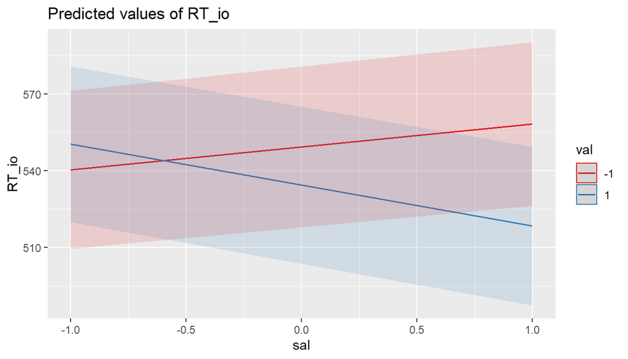

```r
plot_model(randomSlopes_m1, type = "pred", terms = c("sal", "val[minmax]"))
```

```r
summary(randomSlopes_m1)
```

```
## Linear mixed model fit by maximum likelihood . t-tests use Satterthwaite's
##   method [lmerModLmerTest]
## Formula: RT_io ~ 1 + val * sal + (1 + val * sal | participant)
##    Data: raw.data
##
##      AIC      BIC   logLik deviance df.resid
##  57773.9  57870.7 -28872.0  57743.9     4677
##
## Scaled residuals:
##     Min      1Q  Median      3Q     Max
## -3.0272 -0.6398 -0.1107  0.5623  4.9974
##
## Random effects:
##  Groups      Name        Variance  Std.Dev. Corr
##  participant (Intercept)  5557.441  74.548
##              val             7.365   2.714  1.00
##              sal            18.031   4.246  0.18 0.18
##              val:sal       157.206  12.538  0.00 0.00 0.98
##  Residual                12528.215 111.930
## Number of obs: 4692, groups:  participant, 26
##
## Fixed effects:
##             Estimate Std. Error      df t value Pr(>|t|)
## (Intercept)  541.929     14.882  26.002  36.415  < 2e-16 ***
## val           -7.513      2.830 340.896  -2.655  0.00830 **
## sal           -3.525      2.901 125.456  -1.215  0.22651
## val:sal      -12.475      3.712  30.710  -3.361  0.00209 **
## ---
## Signif. codes:  0 '***' 0.001 '**' 0.01 '*' 0.05 '.' 0.1 ' ' 1
##
## Correlation of Fixed Effects:
##         (Intr) val    sal
## val      0.036
## sal      0.064 -0.059
## val:sal -0.010  0.053 -0.393
## convergence code: 0
## boundary (singular) fit: see ?isSingular
```

### 2. with ErrorRates

```r
#Error rates

randomSlopes_m1_err<-glmer(err_trials~1+val*sal + (1+val*sal|participant),
                      data=raw.data,
                      na.action = "na.omit", binomial)


summary(randomSlopes_m1_err)
```

```
## Generalized linear mixed model fit by maximum likelihood (Laplace
##   Approximation) [glmerMod]
##  Family: binomial  ( logit )
## Formula: err_trials ~ 1 + val * sal + (1 + val * sal | participant)
##    Data: raw.data
##
##      AIC      BIC   logLik deviance df.resid
##   1914.0   2005.8   -943.0   1886.0     5186
##
## Scaled residuals:
##     Min      1Q  Median      3Q     Max
## -1.2721 -0.2257 -0.1849 -0.1500  7.4344
##
## Random effects:
##  Groups      Name        Variance  Std.Dev. Corr
##  participant (Intercept) 0.5959951 0.77201
##              val         0.0531378 0.23052  -1.00
##              sal         0.0003339 0.01827  -1.00  1.00
##              val:sal     0.0914649 0.30243  -0.33  0.27  0.28
## Number of obs: 5200, groups:  participant, 26
##
## Fixed effects:
##             Estimate Std. Error z value Pr(>|z|)
## (Intercept)  -3.0782     0.2090 -14.727  < 2e-16 ***
## val          -0.2340     0.1501  -1.559 0.118998
## sal           0.3328     0.1413   2.356 0.018493 *
## val:sal      -0.5571     0.1540  -3.617 0.000298 ***
## ---
## Signif. codes:  0 '***' 0.001 '**' 0.01 '*' 0.05 '.' 0.1 ' ' 1
##
## Correlation of Fixed Effects:
##         (Intr) val    sal
## val     -0.751
## sal     -0.432  0.618
## val:sal  0.315 -0.494 -0.739
## convergence code: 0
## Model failed to converge with max|grad| = 0.00346832 (tol = 0.002, component 1)
```

```r
tab_model(randomSlopes_m1_err, show.se = TRUE,show.stat = TRUE, show.ci = FALSE,show.aic = TRUE, show.loglik = TRUE,
                  dv.labels = "Error Rate")
```

|  | Error Rate |  |  |  |
| --- | --- | --- | --- | --- |
| Predictors | Odds Ratios | std. Error | Statistic | p |
| (Intercept) | 0.05 | 0.01 | -14.73 | **<0.001** |
| val | 0.79 | 0.12 | -1.56 | 0.119 |
| sal | 1.39 | 0.20 | 2.36 | **0.018** |
| val * sal | 0.57 | 0.09 | -3.62 | **<0.001** |
| Random Effects |  |  |  |  |
| σ<sup>2</sup> | 3.29 |  |  |  |
| τ<sub>00</sub> <sub>participant</sub> | 0.60 |  |  |  |
| τ<sub>11</sub> <sub>participant.val</sub> | 0.05 |  |  |  |
| τ<sub>11</sub> <sub>participant.sal</sub> | 0.00 |  |  |  |
| τ<sub>11</sub> <sub>participant.val:sal</sub> | 0.09 |  |  |  |
| ρ<sub>01</sub> | -1.00 |  |  |  |
|  | -1.00 |  |  |  |
|  | -0.33 |  |  |  |
| ICC | 0.12 |  |  |  |
| N <sub>participant</sub> | 26 |  |  |  |
| Observations | 5200 |  |  |  |
| Marginal R<sup>2</sup> / Conditional R<sup>2</sup> | 0.037 / 0.155 |  |  |  |
| AIC | 1914.014 |  |  |  |
| log-Likelihood | -943.007 |  |  |  |

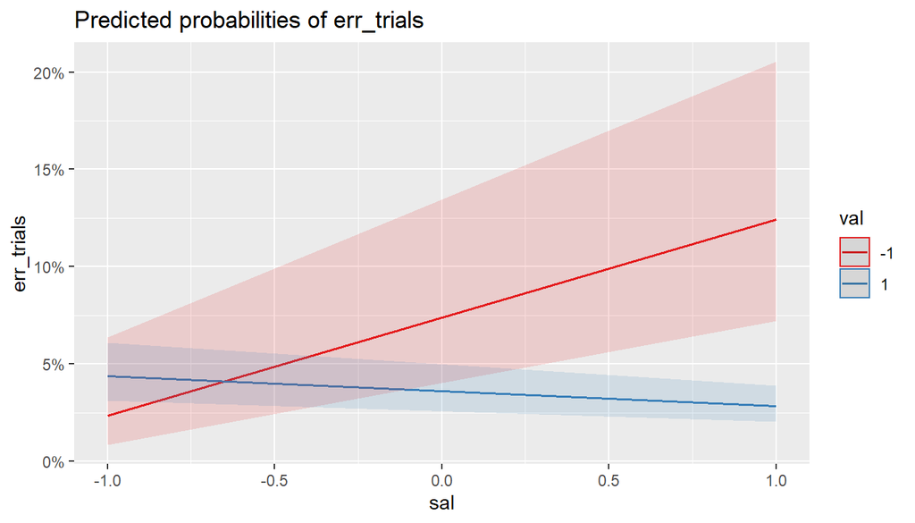

```r
# significant interaction and significant main effect of saliency for both types of randomslopes

plot_model(randomSlopes_m1_err, type = "pred", terms = c("sal", "val[minmax]"))
```

## 2. Model2 : Adding Previous Response and Distance as factors

### 1. with RT

```r
randomSlopes_m2<-lmer(RT_io~1+val*sal + previous_rm_cwp+ Distance_cwp +(1+val*sal + previous_rm_cwp + Distance_cwp|participant),
                      data=raw.data,
                      REML=F,
                      na.action = "na.omit")
tab_model(randomSlopes_m1, randomSlopes_m2, show.se = TRUE,show.stat = TRUE, show.ci = FALSE, show.aic = TRUE, show.loglik = TRUE,
                  dv.labels = "Reaction Time")
```

|  | Reaction Time |  |  |  |  |  |  |  |
| --- | --- | --- | --- | --- | --- | --- | --- | --- |
| Predictors | Estimates | std. Error | Statistic | p | Estimates | std. Error | Statistic | p |
| (Intercept) | 541.93 | 14.88 | 36.41 | **<0.001** | 542.81 | 15.02 | 36.15 | **<0.001** |
| val | -7.51 | 2.83 | -2.66 | **0.008** | -8.46 | 3.89 | -2.18 | **0.030** |
| sal | -3.53 | 2.90 | -1.22 | 0.224 | -2.85 | 2.84 | -1.00 | 0.316 |
| val * sal | -12.48 | 3.71 | -3.36 | **0.001** | -13.36 | 3.90 | -3.42 | **0.001** |
| previous_rm_cwp |  |  |  |  | 6.67 | 4.08 | 1.63 | 0.102 |
| Distance_cwp |  |  |  |  | 1.42 | 0.94 | 1.52 | 0.129 |
| Random Effects |  |  |  |  |  |  |  |  |
| σ<sup>2</sup> | 12528.21 |  |  |  | 12386.03 |  |  |  |
| τ<sub>00</sub> | 5557.44 <sub>participant</sub> |  |  |  | 5662.49 <sub>participant</sub> |  |  |  |
| τ<sub>11</sub> | 7.36 <sub>participant.val</sub> |  |  |  | 192.85 <sub>participant.val</sub> |  |  |  |
|  | 18.03 <sub>participant.sal</sub> |  |  |  | 10.49 <sub>participant.sal</sub> |  |  |  |
|  | 157.21 <sub>participant.val:sal</sub> |  |  |  | 124.33 <sub>participant.previous_rm_cwp</sub> |  |  |  |
|  |  |  |  |  | 5.97 <sub>participant.Distance_cwp</sub> |  |  |  |
|  |  |  |  |  | 196.15 <sub>participant.val:sal</sub> |  |  |  |
| ρ<sub>01</sub> | 1.00 |  |  |  | 0.06 |  |  |  |
|  | 0.18 |  |  |  | 0.00 |  |  |  |
|  | 0.00 |  |  |  | -0.20 |  |  |  |
|  |  |  |  |  | 0.17 |  |  |  |
|  |  |  |  |  | -0.12 |  |  |  |
| N | 26 <sub>participant</sub> |  |  |  | 26 <sub>participant</sub> |  |  |  |
| Observations | 4692 |  |  |  | 4692 |  |  |  |
| Marginal R<sup>2</sup> / Conditional R<sup>2</sup> | 0.020 / NA |  |  |  | 0.023 / NA |  |  |  |
| AIC | 57773.914 |  |  |  | 57767.491 |  |  |  |
| log-Likelihood | -28871.957 |  |  |  | -28855.745 |  |  |  |

```r
summary(randomSlopes_m2)
```

```
## Linear mixed model fit by maximum likelihood . t-tests use Satterthwaite's
##   method [lmerModLmerTest]
## Formula: RT_io ~ 1 + val * sal + previous_rm_cwp + Distance_cwp + (1 +
##     val * sal + previous_rm_cwp + Distance_cwp | participant)
##    Data: raw.data
##
##      AIC      BIC   logLik deviance df.resid
##  57767.5  57948.2 -28855.7  57711.5     4664
##
## Scaled residuals:
##     Min      1Q  Median      3Q     Max
## -3.1572 -0.6421 -0.1099  0.5562  5.1579
##
## Random effects:
##  Groups      Name            Variance  Std.Dev. Corr
##  participant (Intercept)      5662.491  75.250
##              val               192.846  13.887   0.06
##              sal                10.491   3.239   0.00  1.00
##              previous_rm_cwp   124.328  11.150  -0.20  0.19  0.20
##              Distance_cwp        5.973   2.444   0.17  0.13  0.12 -0.52
##              val:sal           196.147  14.005  -0.12  0.95  0.96  0.37 -0.16
##  Residual                    12386.030 111.293
## Number of obs: 4692, groups:  participant, 26
##
## Fixed effects:
##                 Estimate Std. Error       df t value Pr(>|t|)
## (Intercept)     542.8114    15.0163  26.0676  36.148  < 2e-16 ***
## val              -8.4569     3.8876  30.9272  -2.175  0.03737 *
## sal              -2.8483     2.8430 208.9665  -1.002  0.31756
## previous_rm_cwp   6.6683     4.0826  26.1880   1.633  0.11436
## Distance_cwp      1.4224     0.9368  25.9111   1.518  0.14102
## val:sal         -13.3557     3.9042  30.5658  -3.421  0.00179 **
## ---
## Signif. codes:  0 '***' 0.001 '**' 0.01 '*' 0.05 '.' 0.1 ' ' 1
##
## Correlation of Fixed Effects:
##             (Intr) val    sal    prvs__ Dstnc_
## val         -0.068
## sal          0.014  0.103
## prvs_rm_cwp -0.105  0.073  0.004
## Distanc_cwp  0.085  0.051  0.021 -0.371
## val:sal     -0.090  0.506 -0.410  0.153 -0.071
## convergence code: 0
## boundary (singular) fit: see ?isSingular
```

### 2. With ER

```r
randomSlopes_m2_err<-glmer(err_trials~1+val*sal + previous_rm_cwp+ Distance_cwp + (1+val*sal + previous_rm_cwp + Distance_cwp|participant),
                      data=raw.data,
                      binomial,
                      na.action = "na.omit")
#
# randomSlopes_m2b_err<-glmer(err_trials~1+val*sal + previous_rm_cwp+ Distance_cwp + Distance_type_cwp +(1|participant),
#                       data=raw.data,
#                       binomial,
#                       na.action = "na.omit")
tab_model(randomSlopes_m2_err,randomSlopes_m1_err, show.ci = FALSE, show.p = TRUE, show.stat = TRUE, show.aic = TRUE, show.loglik = TRUE)
```

|  | err_trials |  |  | err_trials |  |  |
| --- | --- | --- | --- | --- | --- | --- |
| Predictors | Odds Ratios | Statistic | p | Odds Ratios | Statistic | p |
| (Intercept) | 0.04 | -14.16 | **<0.001** | 0.05 | -14.73 | **<0.001** |
| val | 0.80 | -1.35 | 0.177 | 0.79 | -1.56 | 0.119 |
| sal | 1.44 | 2.44 | **0.014** | 1.39 | 2.36 | **0.018** |
| previous_rm_cwp | 0.73 | -1.81 | 0.070 |  |  |  |
| Distance_cwp | 0.99 | -0.31 | 0.756 |  |  |  |
| val * sal | 0.56 | -3.60 | **<0.001** | 0.57 | -3.62 | **<0.001** |
| Random Effects |  |  |  |  |  |  |
| σ<sup>2</sup> | 3.29 |  |  | 3.29 |  |  |
| τ<sub>00</sub> | 0.66 <sub>participant</sub> |  |  | 0.60 <sub>participant</sub> |  |  |
| τ<sub>11</sub> | 0.10 <sub>participant.val</sub> |  |  | 0.05 <sub>participant.val</sub> |  |  |
|  | 0.00 <sub>participant.sal</sub> |  |  | 0.00 <sub>participant.sal</sub> |  |  |
|  | 0.12 <sub>participant.previous_rm_cwp</sub> |  |  | 0.09 <sub>participant.val:sal</sub> |  |  |
|  | 0.00 <sub>participant.Distance_cwp</sub> |  |  |  |  |  |
|  | 0.11 <sub>participant.val:sal</sub> |  |  |  |  |  |
| ρ<sub>01</sub> | -0.85 |  |  | -1.00 |  |  |
|  | -0.76 |  |  | -1.00 |  |  |
|  | 0.83 |  |  | -0.33 |  |  |
|  | -0.21 |  |  |  |  |  |
|  | -0.19 |  |  |  |  |  |
| ICC | 0.15 |  |  | 0.12 |  |  |
| N | 26 <sub>participant</sub> |  |  | 26 <sub>participant</sub> |  |  |
| Observations | 5199 |  |  | 5200 |  |  |
| Marginal R<sup>2</sup> / Conditional R<sup>2</sup> | 0.044 / 0.183 |  |  | 0.037 / 0.155 |  |  |
| AIC | 1925.771 |  |  | 1914.014 |  |  |
| log-Likelihood | -935.885 |  |  | -943.007 |  |  |

```r
summary(randomSlopes_m2_err)
```

```
## Generalized linear mixed model fit by maximum likelihood (Laplace
##   Approximation) [glmerMod]
##  Family: binomial  ( logit )
## Formula: err_trials ~ 1 + val * sal + previous_rm_cwp + Distance_cwp +
##     (1 + val * sal + previous_rm_cwp + Distance_cwp | participant)
##    Data: raw.data
##
##      AIC      BIC   logLik deviance df.resid
##   1925.8   2102.8   -935.9   1871.8     5172
##
## Scaled residuals:
##     Min      1Q  Median      3Q     Max
## -1.4959 -0.2300 -0.1834 -0.1496  8.3973
##
## Random effects:
##  Groups      Name            Variance Std.Dev. Corr
##  participant (Intercept)     0.657056 0.81059
##              val             0.098185 0.31334  -0.85
##              sal             0.002066 0.04545  -0.76  0.99
##              previous_rm_cwp 0.120747 0.34749   0.83 -0.49 -0.34
##              Distance_cwp    0.002692 0.05189  -0.21  0.57  0.67  0.38
##              val:sal         0.109356 0.33069  -0.19 -0.11 -0.23 -0.69 -0.87
## Number of obs: 5199, groups:  participant, 26
##
## Fixed effects:
##                 Estimate Std. Error z value Pr(>|z|)
## (Intercept)     -3.13735    0.22161 -14.157  < 2e-16 ***
## val             -0.21865    0.16196  -1.350 0.177010
## sal              0.36376    0.14879   2.445 0.014496 *
## previous_rm_cwp -0.31490    0.17391  -1.811 0.070179 .
## Distance_cwp    -0.01239    0.03994  -0.310 0.756343
## val:sal         -0.58602    0.16278  -3.600 0.000318 ***
## ---
## Signif. codes:  0 '***' 0.001 '**' 0.01 '*' 0.05 '.' 0.1 ' ' 1
##
## Correlation of Fixed Effects:
##             (Intr) val    sal    prvs__ Dstnc_
## val         -0.758
## sal         -0.475  0.640
## prvs_rm_cwp  0.288 -0.055 -0.014
## Distanc_cwp -0.029  0.082 -0.002 -0.159
## val:sal      0.372 -0.553 -0.758 -0.100 -0.090
## convergence code: 0
## unable to evaluate scaled gradient
## Model failed to converge: degenerate  Hessian with 1 negative eigenvalues
```

```r
# summary(randomSlopes_m2b_err)
```

## 3. Model3 : Adding the level 2 interaction factors

### with RT

```r
randomSlopes_m3<-lmer(RT_io~1+val*sal*previous_rm_cwp*Distance_cwp+(1+val*sal*previous_rm_cwp*Distance_cwp|participant),
                      data=raw.data,
                      REML=F,
                      na.action = "na.omit")
tab_model(randomSlopes_m3, show.ci = FALSE, show.stat = TRUE, show.aic = TRUE, show.loglik = TRUE)
```

|  | RT_io |  |  |
| --- | --- | --- | --- |
| Predictors | Estimates | Statistic | p |
| (Intercept) | 546.15 | 35.49 | **<0.001** |
| val | -9.40 | -2.46 | **0.014** |
| sal | -2.84 | -0.83 | 0.405 |
| previous_rm_cwp | 6.65 | 0.83 | 0.407 |
| Distance_cwp | 1.95 | 1.23 | 0.217 |
| val * sal | -12.91 | -3.56 | **<0.001** |
| val * previous_rm_cwp | -2.56 | -0.35 | 0.726 |
| sal * previous_rm_cwp | 5.80 | 0.91 | 0.361 |
| val * Distance_cwp | 0.91 | 0.52 | 0.600 |
| sal * Distance_cwp | 3.04 | 1.95 | 0.051 |
| previous_rm_cwp * Distance_cwp | 2.03 | 0.54 | 0.591 |
| (val * sal) * previous_rm_cwp | -4.35 | -0.63 | 0.531 |
| (val * sal) * Distance_cwp | -1.73 | -1.12 | 0.263 |
| (val * previous_rm_cwp) * Distance_cwp | -7.51 | -2.23 | **0.026** |
| (sal * previous_rm_cwp) * Distance_cwp | -1.22 | -0.30 | 0.761 |
| (val * sal *previous_rm_cwp)* Distance_cwp | 0.62 | 0.17 | 0.867 |
| Random Effects |  |  |  |
| σ<sup>2</sup> | 12071.10 |  |  |
| τ<sub>00</sub> <sub>participant</sub> | 5915.45 |  |  |
| τ<sub>11</sub> <sub>participant.val</sub> | 137.80 |  |  |
| τ<sub>11</sub> <sub>participant.sal</sub> | 58.88 |  |  |
| τ<sub>11</sub> <sub>participant.previous_rm_cwp</sub> | 693.73 |  |  |
| τ<sub>11</sub> <sub>participant.Distance_cwp</sub> | 5.71 |  |  |
| τ<sub>11</sub> <sub>participant.val:sal</sub> | 98.59 |  |  |
| τ<sub>11</sub> <sub>participant.val:previous_rm_cwp</sub> | 410.31 |  |  |
| τ<sub>11</sub> <sub>participant.sal:previous_rm_cwp</sub> | 72.95 |  |  |
| τ<sub>11</sub> <sub>participant.val:Distance_cwp</sub> | 19.96 |  |  |
| τ<sub>11</sub> <sub>participant.sal:Distance_cwp</sub> | 3.19 |  |  |
| τ<sub>11</sub> <sub>participant.previous_rm_cwp:Distance_cwp</sub> | 127.00 |  |  |
| τ<sub>11</sub> <sub>participant.val:sal:previous_rm_cwp</sub> | 277.74 |  |  |
| τ<sub>11</sub> <sub>participant.val:sal:Distance_cwp</sub> | 2.62 |  |  |
| τ<sub>11</sub> <sub>participant.val:previous_rm_cwp:Distance_cwp</sub> | 54.18 |  |  |
| τ<sub>11</sub> <sub>participant.sal:previous_rm_cwp:Distance_cwp</sub> | 181.42 |  |  |
| τ<sub>11</sub> <sub>participant.val:sal:previous_rm_cwp:Distance_cwp</sub> | 122.81 |  |  |
| ρ<sub>01</sub> | 0.02 |  |  |
|  | 0.29 |  |  |
|  | 0.08 |  |  |
|  | 0.05 |  |  |
|  | -0.35 |  |  |
|  | -0.33 |  |  |
|  | -0.07 |  |  |
|  | 0.27 |  |  |
|  | -0.09 |  |  |
|  | 0.43 |  |  |
|  | -0.13 |  |  |
|  | 0.87 |  |  |
|  | -0.95 |  |  |
|  | 0.43 |  |  |
|  | -0.48 |  |  |
| N <sub>participant</sub> | 26 |  |  |
| Observations | 4692 |  |  |
| Marginal R<sup>2</sup> / Conditional R<sup>2</sup> | 0.028 / NA |  |  |
| AIC | 57939.259 |  |  |
| log-Likelihood | -28816.630 |  |  |

```r
summary(randomSlopes_m3)
```

```
## Linear mixed model fit by maximum likelihood . t-tests use Satterthwaite's
##   method [lmerModLmerTest]
## Formula: RT_io ~ 1 + val * sal * previous_rm_cwp * Distance_cwp + (1 +
##     val * sal * previous_rm_cwp * Distance_cwp | participant)
##    Data: raw.data
##
##      AIC      BIC   logLik deviance df.resid
##  57939.3  58926.7 -28816.6  57633.3     4539
##
## Scaled residuals:
##     Min      1Q  Median      3Q     Max
## -3.1985 -0.6512 -0.1035  0.5523  4.8843
##
## Random effects:
##  Groups      Name                                 Variance  Std.Dev. Corr
##  participant (Intercept)                           5915.450  76.912
##              val                                    137.803  11.739   0.02
##              sal                                     58.884   7.674   0.29
##              previous_rm_cwp                        693.727  26.339   0.08
##              Distance_cwp                             5.708   2.389   0.05
##              val:sal                                 98.589   9.929  -0.35
##              val:previous_rm_cwp                    410.309  20.256  -0.33
##              sal:previous_rm_cwp                     72.946   8.541  -0.07
##              val:Distance_cwp                        19.958   4.467   0.27
##              sal:Distance_cwp                         3.187   1.785  -0.09
##              previous_rm_cwp:Distance_cwp           127.003  11.270   0.43
##              val:sal:previous_rm_cwp                277.740  16.666  -0.13
##              val:sal:Distance_cwp                     2.620   1.619   0.87
##              val:previous_rm_cwp:Distance_cwp        54.175   7.360  -0.95
##              sal:previous_rm_cwp:Distance_cwp       181.418  13.469   0.43
##              val:sal:previous_rm_cwp:Distance_cwp   122.808  11.082  -0.48
##  Residual                                         12071.102 109.869
##
##
##
##   0.44
##  -0.18 -0.14
##  -0.85 -0.71  0.50
##   0.85  0.46 -0.14 -0.82
##   0.30  0.49 -0.82 -0.71  0.49
```

[output cut: 54 more lines]

```
## val:sal                               0.00142 **
## val:previous_rm_cwp                   0.72793
## sal:previous_rm_cwp                   0.36275
## val:Distance_cwp                      0.60461
## sal:Distance_cwp                      0.05240 .
## previous_rm_cwp:Distance_cwp          0.59599
## val:sal:previous_rm_cwp               0.53384
## val:sal:Distance_cwp                  0.26537
## val:previous_rm_cwp:Distance_cwp      0.03100 *
## sal:previous_rm_cwp:Distance_cwp      0.76476
## val:sal:previous_rm_cwp:Distance_cwp  0.86863
## ---
## Signif. codes:  0 '***' 0.001 '**' 0.01 '*' 0.05 '.' 0.1 ' ' 1
## convergence code: 0
## boundary (singular) fit: see ?isSingular
```